# Risk Factor Analysis

## Outcome Variable

**Outcome Variable:** ever_co

## Predictor Variables

**Intervention Variable:** month

**Adjustment Set:**

unadjusted

## Stratifying Variables

The analysis was stratified on these variable(s):

- agecat
- studyid
- country

## Data Summary

| agecat | studyid | country | month | ever_co | n_cell | n |
| --- | --- | --- | --- | --- | --- | --- |
| 0-24 months | ki0047075b-MAL-ED | BANGLADESH | 1 | 0 | 20 | 263 |
| 0-24 months | ki0047075b-MAL-ED | BANGLADESH | 1 | 1 | 2 | 263 |
| 0-24 months | ki0047075b-MAL-ED | BANGLADESH | 2 | 0 | 18 | 263 |
| 0-24 months | ki0047075b-MAL-ED | BANGLADESH | 2 | 1 | 6 | 263 |
| 0-24 months | ki0047075b-MAL-ED | BANGLADESH | 3 | 0 | 20 | 263 |
| 0-24 months | ki0047075b-MAL-ED | BANGLADESH | 3 | 1 | 6 | 263 |
| 0-24 months | ki0047075b-MAL-ED | BANGLADESH | 4 | 0 | 22 | 263 |
| 0-24 months | ki0047075b-MAL-ED | BANGLADESH | 4 | 1 | 2 | 263 |
| 0-24 months | ki0047075b-MAL-ED | BANGLADESH | 5 | 0 | 15 | 263 |
| 0-24 months | ki0047075b-MAL-ED | BANGLADESH | 5 | 1 | 3 | 263 |
| 0-24 months | ki0047075b-MAL-ED | BANGLADESH | 6 | 0 | 12 | 263 |
| 0-24 months | ki0047075b-MAL-ED | BANGLADESH | 6 | 1 | 1 | 263 |
| 0-24 months | ki0047075b-MAL-ED | BANGLADESH | 7 | 0 | 13 | 263 |
| 0-24 months | ki0047075b-MAL-ED | BANGLADESH | 7 | 1 | 5 | 263 |
| 0-24 months | ki0047075b-MAL-ED | BANGLADESH | 8 | 0 | 28 | 263 |
| 0-24 months | ki0047075b-MAL-ED | BANGLADESH | 8 | 1 | 1 | 263 |
| 0-24 months | ki0047075b-MAL-ED | BANGLADESH | 9 | 0 | 16 | 263 |
| 0-24 months | ki0047075b-MAL-ED | BANGLADESH | 9 | 1 | 6 | 263 |
| 0-24 months | ki0047075b-MAL-ED | BANGLADESH | 10 | 0 | 20 | 263 |
| 0-24 months | ki0047075b-MAL-ED | BANGLADESH | 10 | 1 | 3 | 263 |
| 0-24 months | ki0047075b-MAL-ED | BANGLADESH | 11 | 0 | 14 | 263 |
| 0-24 months | ki0047075b-MAL-ED | BANGLADESH | 11 | 1 | 2 | 263 |
| 0-24 months | ki0047075b-MAL-ED | BANGLADESH | 12 | 0 | 26 | 263 |
| 0-24 months | ki0047075b-MAL-ED | BANGLADESH | 12 | 1 | 2 | 263 |
| 0-24 months | ki0047075b-MAL-ED | BRAZIL | 1 | 0 | 15 | 233 |
| 0-24 months | ki0047075b-MAL-ED | BRAZIL | 1 | 1 | 0 | 233 |
| 0-24 months | ki0047075b-MAL-ED | BRAZIL | 2 | 0 | 25 | 233 |
| 0-24 months | ki0047075b-MAL-ED | BRAZIL | 2 | 1 | 0 | 233 |
| 0-24 months | ki0047075b-MAL-ED | BRAZIL | 3 | 0 | 18 | 233 |
| 0-24 months | ki0047075b-MAL-ED | BRAZIL | 3 | 1 | 0 | 233 |

[output cut: 1818 more lines]

The following strata were considered:

- agecat: 0-24 months, studyid: ki0047075b-MAL-ED, country: BANGLADESH
- agecat: 0-24 months, studyid: ki0047075b-MAL-ED, country: BRAZIL
- agecat: 0-24 months, studyid: ki0047075b-MAL-ED, country: INDIA
- agecat: 0-24 months, studyid: ki0047075b-MAL-ED, country: NEPAL
- agecat: 0-24 months, studyid: ki0047075b-MAL-ED, country: PERU
- agecat: 0-24 months, studyid: ki0047075b-MAL-ED, country: SOUTH AFRICA
- agecat: 0-24 months, studyid: ki0047075b-MAL-ED, country: TANZANIA, UNITED REPUBLIC OF
- agecat: 0-24 months, studyid: ki1000108-CMC-V-BCS-2002, country: INDIA
- agecat: 0-24 months, studyid: ki1000108-IRC, country: INDIA
- agecat: 0-24 months, studyid: ki1000109-EE, country: PAKISTAN
- agecat: 0-24 months, studyid: ki1000109-ResPak, country: PAKISTAN
- agecat: 0-24 months, studyid: ki1000304b-SAS-CompFeed, country: INDIA
- agecat: 0-24 months, studyid: ki1000304b-SAS-FoodSuppl, country: INDIA
- agecat: 0-24 months, studyid: ki1017093-NIH-Birth, country: BANGLADESH
- agecat: 0-24 months, studyid: ki1066203-TanzaniaChild2, country: TANZANIA, UNITED REPUBLIC OF
- agecat: 0-24 months, studyid: ki1101329-Keneba, country: GAMBIA
- agecat: 0-24 months, studyid: ki1112895-Guatemala BSC, country: GUATEMALA
- agecat: 0-24 months, studyid: ki1112895-iLiNS-Zinc, country: BURKINA FASO
- agecat: 0-24 months, studyid: ki1113344-GMS-Nepal, country: NEPAL
- agecat: 0-24 months, studyid: ki1114097-CMIN, country: BANGLADESH
- agecat: 0-24 months, studyid: ki1114097-CONTENT, country: PERU
- agecat: 0-24 months, studyid: ki1119695-PROBIT, country: BELARUS
- agecat: 0-24 months, studyid: ki1126311-ZVITAMBO, country: ZIMBABWE
- agecat: 0-24 months, studyid: ki1148112-LCNI-5, country: MALAWI
- agecat: 0-24 months, studyid: kiGH5241-JiVitA-3, country: BANGLADESH
- agecat: 0-24 months, studyid: kiGH5241-JiVitA-4, country: BANGLADESH
- agecat: 0-6 months, studyid: ki0047075b-MAL-ED, country: BANGLADESH
- agecat: 0-6 months, studyid: ki0047075b-MAL-ED, country: BRAZIL
- agecat: 0-6 months, studyid: ki0047075b-MAL-ED, country: INDIA
- agecat: 0-6 months, studyid: ki0047075b-MAL-ED, country: NEPAL
- agecat: 0-6 months, studyid: ki0047075b-MAL-ED, country: PERU
- agecat: 0-6 months, studyid: ki0047075b-MAL-ED, country: SOUTH AFRICA
- agecat: 0-6 months, studyid: ki0047075b-MAL-ED, country: TANZANIA, UNITED REPUBLIC OF
- agecat: 0-6 months, studyid: ki1000108-CMC-V-BCS-2002, country: INDIA
- agecat: 0-6 months, studyid: ki1000108-IRC, country: INDIA
- agecat: 0-6 months, studyid: ki1000109-EE, country: PAKISTAN
- agecat: 0-6 months, studyid: ki1000109-ResPak, country: PAKISTAN
- agecat: 0-6 months, studyid: ki1000304b-SAS-CompFeed, country: INDIA
- agecat: 0-6 months, studyid: ki1000304b-SAS-FoodSuppl, country: INDIA
- agecat: 0-6 months, studyid: ki1017093-NIH-Birth, country: BANGLADESH
- agecat: 0-6 months, studyid: ki1066203-TanzaniaChild2, country: TANZANIA, UNITED REPUBLIC OF
- agecat: 0-6 months, studyid: ki1101329-Keneba, country: GAMBIA
- agecat: 0-6 months, studyid: ki1112895-Guatemala BSC, country: GUATEMALA
- agecat: 0-6 months, studyid: ki1113344-GMS-Nepal, country: NEPAL
- agecat: 0-6 months, studyid: ki1114097-CMIN, country: BANGLADESH
- agecat: 0-6 months, studyid: ki1114097-CONTENT, country: PERU
- agecat: 0-6 months, studyid: ki1119695-PROBIT, country: BELARUS
- agecat: 0-6 months, studyid: ki1126311-ZVITAMBO, country: ZIMBABWE
- agecat: 0-6 months, studyid: ki1148112-LCNI-5, country: MALAWI
- agecat: 0-6 months, studyid: kiGH5241-JiVitA-3, country: BANGLADESH
- agecat: 0-6 months, studyid: kiGH5241-JiVitA-4, country: BANGLADESH
- agecat: 6-24 months, studyid: ki0047075b-MAL-ED, country: BANGLADESH
- agecat: 6-24 months, studyid: ki0047075b-MAL-ED, country: BRAZIL
- agecat: 6-24 months, studyid: ki0047075b-MAL-ED, country: INDIA
- agecat: 6-24 months, studyid: ki0047075b-MAL-ED, country: NEPAL
- agecat: 6-24 months, studyid: ki0047075b-MAL-ED, country: PERU
- agecat: 6-24 months, studyid: ki0047075b-MAL-ED, country: SOUTH AFRICA
- agecat: 6-24 months, studyid: ki0047075b-MAL-ED, country: TANZANIA, UNITED REPUBLIC OF
- agecat: 6-24 months, studyid: ki1000108-CMC-V-BCS-2002, country: INDIA
- agecat: 6-24 months, studyid: ki1000108-IRC, country: INDIA
- agecat: 6-24 months, studyid: ki1000109-EE, country: PAKISTAN
- agecat: 6-24 months, studyid: ki1000109-ResPak, country: PAKISTAN
- agecat: 6-24 months, studyid: ki1000304b-SAS-CompFeed, country: INDIA
- agecat: 6-24 months, studyid: ki1000304b-SAS-FoodSuppl, country: INDIA
- agecat: 6-24 months, studyid: ki1017093-NIH-Birth, country: BANGLADESH
- agecat: 6-24 months, studyid: ki1066203-TanzaniaChild2, country: TANZANIA, UNITED REPUBLIC OF
- agecat: 6-24 months, studyid: ki1101329-Keneba, country: GAMBIA
- agecat: 6-24 months, studyid: ki1112895-Guatemala BSC, country: GUATEMALA
- agecat: 6-24 months, studyid: ki1112895-iLiNS-Zinc, country: BURKINA FASO
- agecat: 6-24 months, studyid: ki1113344-GMS-Nepal, country: NEPAL
- agecat: 6-24 months, studyid: ki1114097-CMIN, country: BANGLADESH
- agecat: 6-24 months, studyid: ki1114097-CONTENT, country: PERU
- agecat: 6-24 months, studyid: ki1119695-PROBIT, country: BELARUS
- agecat: 6-24 months, studyid: ki1126311-ZVITAMBO, country: ZIMBABWE
- agecat: 6-24 months, studyid: ki1148112-LCNI-5, country: MALAWI
- agecat: 6-24 months, studyid: kiGH5241-JiVitA-3, country: BANGLADESH
- agecat: 6-24 months, studyid: kiGH5241-JiVitA-4, country: BANGLADESH

### Dropped Strata

Some strata were dropped due to rare outcomes:

- agecat: 0-24 months, studyid: ki0047075b-MAL-ED, country: BANGLADESH
- agecat: 0-24 months, studyid: ki0047075b-MAL-ED, country: BRAZIL
- agecat: 0-24 months, studyid: ki0047075b-MAL-ED, country: INDIA
- agecat: 0-24 months, studyid: ki0047075b-MAL-ED, country: NEPAL
- agecat: 0-24 months, studyid: ki0047075b-MAL-ED, country: PERU
- agecat: 0-24 months, studyid: ki0047075b-MAL-ED, country: SOUTH AFRICA
- agecat: 0-24 months, studyid: ki0047075b-MAL-ED, country: TANZANIA, UNITED REPUBLIC OF
- agecat: 0-24 months, studyid: ki1000108-CMC-V-BCS-2002, country: INDIA
- agecat: 0-24 months, studyid: ki1000108-IRC, country: INDIA
- agecat: 0-24 months, studyid: ki1000109-EE, country: PAKISTAN
- agecat: 0-24 months, studyid: ki1000109-ResPak, country: PAKISTAN
- agecat: 0-24 months, studyid: ki1000304b-SAS-FoodSuppl, country: INDIA
- agecat: 0-24 months, studyid: ki1066203-TanzaniaChild2, country: TANZANIA, UNITED REPUBLIC OF
- agecat: 0-24 months, studyid: ki1112895-Guatemala BSC, country: GUATEMALA
- agecat: 0-24 months, studyid: ki1113344-GMS-Nepal, country: NEPAL
- agecat: 0-24 months, studyid: ki1114097-CMIN, country: BANGLADESH
- agecat: 0-24 months, studyid: ki1114097-CONTENT, country: PERU
- agecat: 0-24 months, studyid: ki1119695-PROBIT, country: BELARUS
- agecat: 0-24 months, studyid: ki1148112-LCNI-5, country: MALAWI
- agecat: 0-6 months, studyid: ki0047075b-MAL-ED, country: BANGLADESH
- agecat: 0-6 months, studyid: ki0047075b-MAL-ED, country: BRAZIL
- agecat: 0-6 months, studyid: ki0047075b-MAL-ED, country: INDIA
- agecat: 0-6 months, studyid: ki0047075b-MAL-ED, country: NEPAL
- agecat: 0-6 months, studyid: ki0047075b-MAL-ED, country: PERU
- agecat: 0-6 months, studyid: ki0047075b-MAL-ED, country: SOUTH AFRICA
- agecat: 0-6 months, studyid: ki0047075b-MAL-ED, country: TANZANIA, UNITED REPUBLIC OF
- agecat: 0-6 months, studyid: ki1000108-CMC-V-BCS-2002, country: INDIA
- agecat: 0-6 months, studyid: ki1000108-IRC, country: INDIA
- agecat: 0-6 months, studyid: ki1000109-EE, country: PAKISTAN
- agecat: 0-6 months, studyid: ki1000109-ResPak, country: PAKISTAN
- agecat: 0-6 months, studyid: ki1000304b-SAS-FoodSuppl, country: INDIA
- agecat: 0-6 months, studyid: ki1017093-NIH-Birth, country: BANGLADESH
- agecat: 0-6 months, studyid: ki1066203-TanzaniaChild2, country: TANZANIA, UNITED REPUBLIC OF
- agecat: 0-6 months, studyid: ki1101329-Keneba, country: GAMBIA
- agecat: 0-6 months, studyid: ki1112895-Guatemala BSC, country: GUATEMALA
- agecat: 0-6 months, studyid: ki1113344-GMS-Nepal, country: NEPAL
- agecat: 0-6 months, studyid: ki1114097-CMIN, country: BANGLADESH
- agecat: 0-6 months, studyid: ki1114097-CONTENT, country: PERU
- agecat: 0-6 months, studyid: ki1119695-PROBIT, country: BELARUS
- agecat: 0-6 months, studyid: ki1148112-LCNI-5, country: MALAWI
- agecat: 0-6 months, studyid: kiGH5241-JiVitA-4, country: BANGLADESH
- agecat: 6-24 months, studyid: ki0047075b-MAL-ED, country: BANGLADESH
- agecat: 6-24 months, studyid: ki0047075b-MAL-ED, country: BRAZIL
- agecat: 6-24 months, studyid: ki0047075b-MAL-ED, country: INDIA
- agecat: 6-24 months, studyid: ki0047075b-MAL-ED, country: NEPAL
- agecat: 6-24 months, studyid: ki0047075b-MAL-ED, country: PERU
- agecat: 6-24 months, studyid: ki0047075b-MAL-ED, country: SOUTH AFRICA
- agecat: 6-24 months, studyid: ki0047075b-MAL-ED, country: TANZANIA, UNITED REPUBLIC OF
- agecat: 6-24 months, studyid: ki1000108-CMC-V-BCS-2002, country: INDIA
- agecat: 6-24 months, studyid: ki1000108-IRC, country: INDIA
- agecat: 6-24 months, studyid: ki1000109-EE, country: PAKISTAN
- agecat: 6-24 months, studyid: ki1000109-ResPak, country: PAKISTAN
- agecat: 6-24 months, studyid: ki1000304b-SAS-FoodSuppl, country: INDIA
- agecat: 6-24 months, studyid: ki1066203-TanzaniaChild2, country: TANZANIA, UNITED REPUBLIC OF
- agecat: 6-24 months, studyid: ki1112895-Guatemala BSC, country: GUATEMALA
- agecat: 6-24 months, studyid: ki1113344-GMS-Nepal, country: NEPAL
- agecat: 6-24 months, studyid: ki1114097-CMIN, country: BANGLADESH
- agecat: 6-24 months, studyid: ki1114097-CONTENT, country: PERU
- agecat: 6-24 months, studyid: ki1119695-PROBIT, country: BELARUS
- agecat: 6-24 months, studyid: ki1148112-LCNI-5, country: MALAWI

## Methods Detail

We’re interested in the causal parameters $E[Y_a]$ for all values of $a \in \mathcal{A}$. These parameters represent the mean outcome if, possibly contrary to fact, we intervened to set all units to have $A=a$. Under the randomization and positivity assumptions, these are identified by the statistical parameters $\psi_a=E_W[E_{Y|A,W}(Y|A=a,W)]$. In addition, we’re interested in the mean of $Y$, $E[Y]$ under no intervention (the observed mean). We will estimate these parameters by using SuperLearner to fit the relevant likelihood factors – $E_{Y|A,W}(Y|A=a,W)$ and $p(A=a|W)$, and then updating our likelihood fit using a joint TMLE.

For unadjusted analyses ($W=\{\}$), initial likelihoods were estimated using Lrnr_glm to estimate the simple $E(Y|A)$ and Lrnr_mean to estimate $p(A)$. For adjusted analyses, a small library containing Lrnr_glmnet, Lrnr_xgboost, and Lrnr_mean was used.

Having estimated these parameters, we will then use the delta method to estimate relative risks and attributable risks relative to a prespecified baseline level of $A$.

# Results Detail

## Results Plots

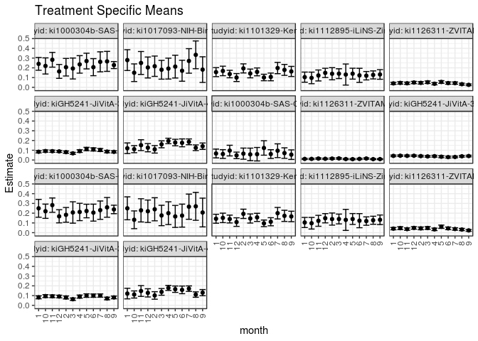

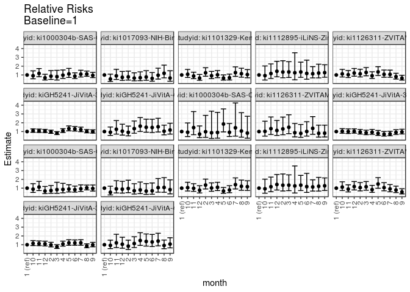

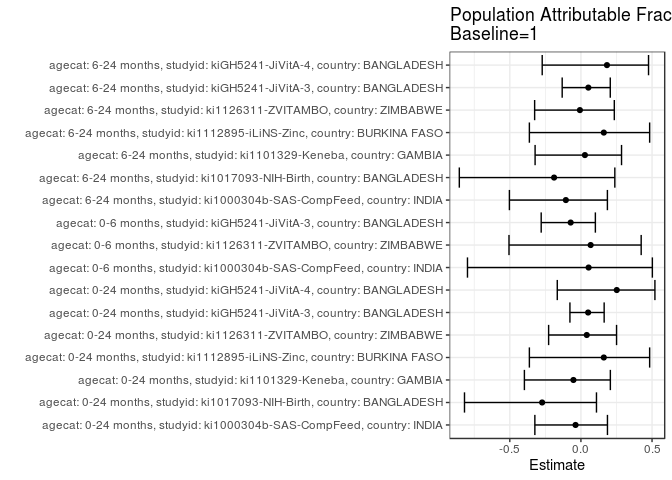

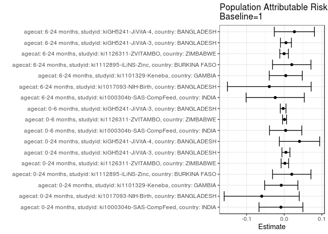

## Results Table

### Parameter: TSM

| agecat | studyid | country | intervention_level | baseline_level | estimate | ci_lower | ci_upper |
| --- | --- | --- | --- | --- | --- | --- | --- |
| 0-24 months | ki1000304b-SAS-CompFeed | INDIA | 1 | NA | 0.2407407 | 0.1752626 | 0.3062189 |
| 0-24 months | ki1000304b-SAS-CompFeed | INDIA | 2 | NA | 0.2065217 | 0.1163837 | 0.2966598 |
| 0-24 months | ki1000304b-SAS-CompFeed | INDIA | 3 | NA | 0.1931818 | 0.0856080 | 0.3007557 |
| 0-24 months | ki1000304b-SAS-CompFeed | INDIA | 4 | NA | 0.2352941 | 0.1455589 | 0.3250293 |
| 0-24 months | ki1000304b-SAS-CompFeed | INDIA | 5 | NA | 0.2696629 | 0.1890236 | 0.3503022 |
| 0-24 months | ki1000304b-SAS-CompFeed | INDIA | 6 | NA | 0.2068966 | 0.1193738 | 0.2944193 |
| 0-24 months | ki1000304b-SAS-CompFeed | INDIA | 7 | NA | 0.2619048 | 0.1593920 | 0.3644175 |
| 0-24 months | ki1000304b-SAS-CompFeed | INDIA | 8 | NA | 0.2662722 | 0.1637571 | 0.3687872 |
| 0-24 months | ki1000304b-SAS-CompFeed | INDIA | 9 | NA | 0.2282609 | 0.1922326 | 0.2642891 |
| 0-24 months | ki1000304b-SAS-CompFeed | INDIA | 10 | NA | 0.2195122 | 0.1366964 | 0.3023280 |
| 0-24 months | ki1000304b-SAS-CompFeed | INDIA | 11 | NA | 0.2827586 | 0.2071966 | 0.3583206 |
| 0-24 months | ki1000304b-SAS-CompFeed | INDIA | 12 | NA | 0.1632653 | 0.0919343 | 0.2345964 |
| 0-24 months | ki1017093-NIH-Birth | BANGLADESH | 1 | NA | 0.2794118 | 0.1726765 | 0.3861470 |
| 0-24 months | ki1017093-NIH-Birth | BANGLADESH | 2 | NA | 0.2166667 | 0.1123413 | 0.3209921 |
| 0-24 months | ki1017093-NIH-Birth | BANGLADESH | 3 | NA | 0.1803279 | 0.0837710 | 0.2768847 |
| 0-24 months | ki1017093-NIH-Birth | BANGLADESH | 4 | NA | 0.1923077 | 0.0851025 | 0.2995129 |
| 0-24 months | ki1017093-NIH-Birth | BANGLADESH | 5 | NA | 0.2127660 | 0.0956677 | 0.3298642 |
| 0-24 months | ki1017093-NIH-Birth | BANGLADESH | 6 | NA | 0.1702128 | 0.0626835 | 0.2777421 |
| 0-24 months | ki1017093-NIH-Birth | BANGLADESH | 7 | NA | 0.2708333 | 0.1450161 | 0.3966506 |
| 0-24 months | ki1017093-NIH-Birth | BANGLADESH | 8 | NA | 0.3333333 | 0.1906526 | 0.4760141 |
| 0-24 months | ki1017093-NIH-Birth | BANGLADESH | 9 | NA | 0.1818182 | 0.0501190 | 0.3135173 |
| 0-24 months | ki1017093-NIH-Birth | BANGLADESH | 10 | NA | 0.1500000 | 0.0595776 | 0.2404224 |
| 0-24 months | ki1017093-NIH-Birth | BANGLADESH | 11 | NA | 0.2500000 | 0.1322136 | 0.3677864 |
| 0-24 months | ki1017093-NIH-Birth | BANGLADESH | 12 | NA | 0.2037037 | 0.0961968 | 0.3112106 |
| 0-24 months | ki1101329-Keneba | GAMBIA | 1 | NA | 0.1561181 | 0.1098996 | 0.2023367 |
| 0-24 months | ki1101329-Keneba | GAMBIA | 2 | NA | 0.1942446 | 0.1477314 | 0.2407578 |
| 0-24 months | ki1101329-Keneba | GAMBIA | 3 | NA | 0.1422414 | 0.0972868 | 0.1871960 |
| 0-24 months | ki1101329-Keneba | GAMBIA | 4 | NA | 0.1587302 | 0.1183689 | 0.1990914 |
| 0-24 months | ki1101329-Keneba | GAMBIA | 5 | NA | 0.1009464 | 0.0677775 | 0.1341153 |
| 0-24 months | ki1101329-Keneba | GAMBIA | 6 | NA | 0.1068376 | 0.0672516 | 0.1464236 |

[output cut: 174 more lines]

### Parameter: E(Y)

| agecat | studyid | country | intervention_level | baseline_level | estimate | ci_lower | ci_upper |
| --- | --- | --- | --- | --- | --- | --- | --- |
| 0-24 months | ki1000304b-SAS-CompFeed | INDIA | NA | NA | 0.2319894 | 0.1917264 | 0.2722524 |
| 0-24 months | ki1017093-NIH-Birth | BANGLADESH | NA | NA | 0.2195513 | 0.1870467 | 0.2520558 |
| 0-24 months | ki1101329-Keneba | GAMBIA | NA | NA | 0.1483007 | 0.1353925 | 0.1612090 |
| 0-24 months | ki1112895-iLiNS-Zinc | BURKINA FASO | NA | NA | 0.1246554 | 0.1041227 | 0.1451882 |
| 0-24 months | ki1126311-ZVITAMBO | ZIMBABWE | NA | NA | 0.0423899 | 0.0390454 | 0.0457344 |
| 0-24 months | kiGH5241-JiVitA-3 | BANGLADESH | NA | NA | 0.0888460 | 0.0849398 | 0.0927521 |
| 0-24 months | kiGH5241-JiVitA-4 | BANGLADESH | NA | NA | 0.1613377 | 0.1500062 | 0.1726692 |
| 0-6 months | ki1000304b-SAS-CompFeed | INDIA | NA | NA | 0.0704787 | 0.0478990 | 0.0930584 |
| 0-6 months | ki1126311-ZVITAMBO | ZIMBABWE | NA | NA | 0.0120612 | 0.0102430 | 0.0138795 |
| 0-6 months | kiGH5241-JiVitA-3 | BANGLADESH | NA | NA | 0.0396778 | 0.0371765 | 0.0421791 |
| 6-24 months | ki1000304b-SAS-CompFeed | INDIA | NA | NA | 0.2260619 | 0.1909133 | 0.2612105 |
| 6-24 months | ki1017093-NIH-Birth | BANGLADESH | NA | NA | 0.2103321 | 0.1759902 | 0.2446740 |
| 6-24 months | ki1101329-Keneba | GAMBIA | NA | NA | 0.1469835 | 0.1337108 | 0.1602563 |
| 6-24 months | ki1112895-iLiNS-Zinc | BURKINA FASO | NA | NA | 0.1246554 | 0.1041227 | 0.1451882 |
| 6-24 months | ki1126311-ZVITAMBO | ZIMBABWE | NA | NA | 0.0410617 | 0.0373214 | 0.0448020 |
| 6-24 months | kiGH5241-JiVitA-3 | BANGLADESH | NA | NA | 0.0869213 | 0.0822621 | 0.0915805 |
| 6-24 months | kiGH5241-JiVitA-4 | BANGLADESH | NA | NA | 0.1477252 | 0.1371297 | 0.1583206 |

### Parameter: RR

| agecat | studyid | country | intervention_level | baseline_level | estimate | ci_lower | ci_upper |
| --- | --- | --- | --- | --- | --- | --- | --- |
| 0-24 months | ki1000304b-SAS-CompFeed | INDIA | 1 | 1 | 1.0000000 | 1.0000000 | 1.0000000 |
| 0-24 months | ki1000304b-SAS-CompFeed | INDIA | 2 | 1 | 0.8578595 | 0.4915733 | 1.4970768 |
| 0-24 months | ki1000304b-SAS-CompFeed | INDIA | 3 | 1 | 0.8024476 | 0.4213646 | 1.5281828 |
| 0-24 months | ki1000304b-SAS-CompFeed | INDIA | 4 | 1 | 0.9773756 | 0.6094165 | 1.5675043 |
| 0-24 months | ki1000304b-SAS-CompFeed | INDIA | 5 | 1 | 1.1201383 | 0.7184143 | 1.7464990 |
| 0-24 months | ki1000304b-SAS-CompFeed | INDIA | 6 | 1 | 0.8594164 | 0.5939951 | 1.2434390 |
| 0-24 months | ki1000304b-SAS-CompFeed | INDIA | 7 | 1 | 1.0879121 | 0.7697159 | 1.5376488 |
| 0-24 months | ki1000304b-SAS-CompFeed | INDIA | 8 | 1 | 1.1060537 | 0.8494673 | 1.4401434 |
| 0-24 months | ki1000304b-SAS-CompFeed | INDIA | 9 | 1 | 0.9481605 | 0.6938978 | 1.2955919 |
| 0-24 months | ki1000304b-SAS-CompFeed | INDIA | 10 | 1 | 0.9118199 | 0.5671732 | 1.4658935 |
| 0-24 months | ki1000304b-SAS-CompFeed | INDIA | 11 | 1 | 1.1745358 | 0.7988632 | 1.7268719 |
| 0-24 months | ki1000304b-SAS-CompFeed | INDIA | 12 | 1 | 0.6781790 | 0.4247632 | 1.0827838 |
| 0-24 months | ki1017093-NIH-Birth | BANGLADESH | 1 | 1 | 1.0000000 | 1.0000000 | 1.0000000 |
| 0-24 months | ki1017093-NIH-Birth | BANGLADESH | 2 | 1 | 0.7754386 | 0.4193897 | 1.4337621 |
| 0-24 months | ki1017093-NIH-Birth | BANGLADESH | 3 | 1 | 0.6453840 | 0.3343197 | 1.2458748 |
| 0-24 months | ki1017093-NIH-Birth | BANGLADESH | 4 | 1 | 0.6882591 | 0.3501544 | 1.3528333 |
| 0-24 months | ki1017093-NIH-Birth | BANGLADESH | 5 | 1 | 0.7614782 | 0.3896776 | 1.4880224 |
| 0-24 months | ki1017093-NIH-Birth | BANGLADESH | 6 | 1 | 0.6091825 | 0.2911586 | 1.2745744 |
| 0-24 months | ki1017093-NIH-Birth | BANGLADESH | 7 | 1 | 0.9692982 | 0.5311940 | 1.7687306 |
| 0-24 months | ki1017093-NIH-Birth | BANGLADESH | 8 | 1 | 1.1929825 | 0.6721630 | 2.1173541 |
| 0-24 months | ki1017093-NIH-Birth | BANGLADESH | 9 | 1 | 0.6507177 | 0.2869116 | 1.4758326 |
| 0-24 months | ki1017093-NIH-Birth | BANGLADESH | 10 | 1 | 0.5368421 | 0.2629711 | 1.0959360 |
| 0-24 months | ki1017093-NIH-Birth | BANGLADESH | 11 | 1 | 0.8947368 | 0.4878365 | 1.6410295 |
| 0-24 months | ki1017093-NIH-Birth | BANGLADESH | 12 | 1 | 0.7290448 | 0.3800233 | 1.3986151 |
| 0-24 months | ki1101329-Keneba | GAMBIA | 1 | 1 | 1.0000000 | 1.0000000 | 1.0000000 |
| 0-24 months | ki1101329-Keneba | GAMBIA | 2 | 1 | 1.2442154 | 0.8502178 | 1.8207948 |
| 0-24 months | ki1101329-Keneba | GAMBIA | 3 | 1 | 0.9111137 | 0.5908852 | 1.4048890 |
| 0-24 months | ki1101329-Keneba | GAMBIA | 4 | 1 | 1.0167310 | 0.6882075 | 1.5020788 |
| 0-24 months | ki1101329-Keneba | GAMBIA | 5 | 1 | 0.6466024 | 0.4154883 | 1.0062731 |
| 0-24 months | ki1101329-Keneba | GAMBIA | 6 | 1 | 0.6843382 | 0.4258898 | 1.0996243 |

[output cut: 174 more lines]

### Parameter: PAR

| agecat | studyid | country | intervention_level | baseline_level | estimate | ci_lower | ci_upper |
| --- | --- | --- | --- | --- | --- | --- | --- |
| 0-24 months | ki1000304b-SAS-CompFeed | INDIA | 1 | NA | -0.0087513 | -0.0671061 | 0.0496035 |
| 0-24 months | ki1017093-NIH-Birth | BANGLADESH | 1 | NA | -0.0598605 | -0.1596903 | 0.0399694 |
| 0-24 months | ki1101329-Keneba | GAMBIA | 1 | NA | -0.0078174 | -0.0520349 | 0.0364000 |
| 0-24 months | ki1112895-iLiNS-Zinc | BURKINA FASO | 1 | NA | 0.0200529 | -0.0310272 | 0.0711330 |
| 0-24 months | ki1126311-ZVITAMBO | ZIMBABWE | 1 | NA | 0.0017395 | -0.0082817 | 0.0117607 |
| 0-24 months | kiGH5241-JiVitA-3 | BANGLADESH | 1 | NA | 0.0044992 | -0.0061563 | 0.0151546 |
| 0-24 months | kiGH5241-JiVitA-4 | BANGLADESH | 1 | NA | 0.0406481 | -0.0129581 | 0.0942542 |
| 0-6 months | ki1000304b-SAS-CompFeed | INDIA | 1 | NA | 0.0038121 | -0.0391676 | 0.0467917 |
| 0-6 months | ki1126311-ZVITAMBO | ZIMBABWE | 1 | NA | 0.0008253 | -0.0045702 | 0.0062208 |
| 0-6 months | kiGH5241-JiVitA-3 | BANGLADESH | 1 | NA | -0.0028586 | -0.0103774 | 0.0046601 |
| 6-24 months | ki1000304b-SAS-CompFeed | INDIA | 1 | NA | -0.0239381 | -0.1012991 | 0.0534229 |
| 6-24 months | ki1017093-NIH-Birth | BANGLADESH | 1 | NA | -0.0396679 | -0.1509946 | 0.0716588 |
| 6-24 months | ki1101329-Keneba | GAMBIA | 1 | NA | 0.0041264 | -0.0398368 | 0.0480896 |
| 6-24 months | ki1112895-iLiNS-Zinc | BURKINA FASO | 1 | NA | 0.0200529 | -0.0310272 | 0.0711330 |
| 6-24 months | ki1126311-ZVITAMBO | ZIMBABWE | 1 | NA | -0.0002917 | -0.0116478 | 0.0110644 |
| 6-24 months | kiGH5241-JiVitA-3 | BANGLADESH | 1 | NA | 0.0045431 | -0.0100607 | 0.0191468 |
| 6-24 months | kiGH5241-JiVitA-4 | BANGLADESH | 1 | NA | 0.0270355 | -0.0263767 | 0.0804477 |

### Parameter: PAF

| agecat | studyid | country | intervention_level | baseline_level | estimate | ci_lower | ci_upper |
| --- | --- | --- | --- | --- | --- | --- | --- |
| 0-24 months | ki1000304b-SAS-CompFeed | INDIA | 1 | NA | -0.0377229 | -0.3237885 | 0.1865250 |
| 0-24 months | ki1017093-NIH-Birth | BANGLADESH | 1 | NA | -0.2726492 | -0.8184535 | 0.1093333 |
| 0-24 months | ki1101329-Keneba | GAMBIA | 1 | NA | -0.0527133 | -0.3973538 | 0.2069258 |
| 0-24 months | ki1112895-iLiNS-Zinc | BURKINA FASO | 1 | NA | 0.1608668 | -0.3623252 | 0.4831304 |
| 0-24 months | ki1126311-ZVITAMBO | ZIMBABWE | 1 | NA | 0.0410356 | -0.2270340 | 0.2505401 |
| 0-24 months | kiGH5241-JiVitA-3 | BANGLADESH | 1 | NA | 0.0506401 | -0.0772658 | 0.1633594 |
| 0-24 months | kiGH5241-JiVitA-4 | BANGLADESH | 1 | NA | 0.2519441 | -0.1662293 | 0.5201735 |
| 0-6 months | ki1000304b-SAS-CompFeed | INDIA | 1 | NA | 0.0540881 | -0.7974566 | 0.5022136 |
| 0-6 months | ki1126311-ZVITAMBO | ZIMBABWE | 1 | NA | 0.0684249 | -0.5056093 | 0.4236007 |
| 0-6 months | kiGH5241-JiVitA-3 | BANGLADESH | 1 | NA | -0.0720460 | -0.2792307 | 0.1015830 |
| 6-24 months | ki1000304b-SAS-CompFeed | INDIA | 1 | NA | -0.1058917 | -0.5027486 | 0.1861603 |
| 6-24 months | ki1017093-NIH-Birth | BANGLADESH | 1 | NA | -0.1885965 | -0.8548494 | 0.2383416 |
| 6-24 months | ki1101329-Keneba | GAMBIA | 1 | NA | 0.0280739 | -0.3221500 | 0.2855271 |
| 6-24 months | ki1112895-iLiNS-Zinc | BURKINA FASO | 1 | NA | 0.1608668 | -0.3623252 | 0.4831304 |
| 6-24 months | ki1126311-ZVITAMBO | ZIMBABWE | 1 | NA | -0.0071039 | -0.3253666 | 0.2347338 |
| 6-24 months | kiGH5241-JiVitA-3 | BANGLADESH | 1 | NA | 0.0522665 | -0.1317104 | 0.2063352 |
| 6-24 months | kiGH5241-JiVitA-4 | BANGLADESH | 1 | NA | 0.1830123 | -0.2721494 | 0.4753219 |